# Week 2 Notes Part 3 Hypothesis Testing and Power Analysis

## 4.2 Shapiro-Wilk Test: Formal Normality Testing

The Shapiro-Wilk test provides a formal hypothesis test of normality, defined by the following statistic:

$$W=\frac{(\sum_{i=1}^{n}a_ix_i)^2}{\sum_{i=1}^{n}(x_1-\bar{x})^2}$$

In essence, the Shapiro-Wilk test tests the null hypothesis that $x_1,...,x_n$ came from a normally distributed population. Therefore, a non-significant value (i.e $p > 0.05$) indicates the data is not significantly different from a normal distribution and is itself normally distributed. We can see this in the following example. First, we will load a dataset from the `medicaldata` package:

```r
# install.packages("medicaldata")
library(medicaldata)
head(blood_storage)
```

```
##   RBC.Age.Group Median.RBC.Age  Age AA FamHx  PVol TVol T.Stage bGS BN+
## 1             3             25 72.1  0     0  54.0    3       1   3   0
## 2             3             25 73.6  0     0  43.2    3       2   2   0
## 3             3             25 67.5  0     0 102.7    1       1   3   0
## 4             2             15 65.8  0     0  46.0    1       1   1   0
## 5             2             15 63.2  0     0  60.0    2       1   2   0
## 6             3             25 65.4  0     0  45.9    2       1   1   0
##   OrganConfined PreopPSA PreopTherapy Units sGS AnyAdjTherapy AdjRadTherapy
## 1             0    14.08            1     6   1             0             0
## 2             1    10.50            0     2   3             0             0
## 3             1     6.98            1     1   1             0             0
## 4             1     4.40            0     2   3             0             0
## 5             1    21.40            0     3   3             0             0
## 6             0     5.10            0     1   3             0             0
##   Recurrence Censor TimeToRecurrence
## 1          1      0             2.67
## 2          1      0            47.63
## 3          0      1            14.10
## 4          0      1            59.47
## 5          0      1             1.23
## 6          0      1            74.70
```

next, we will create a function that loops through columns of the data set and performs a Shapiro-wilk test of normality on each column independently. In the function arguments, `DT` is the data table containing the data and `cols` contains the column numbers that the test should be performed on.

```r
normalityfindR <- function(DT, cols){
  finDT <- data.table()
  for(i in 1:length(cols)){
    if(length(table(as.numeric(DT[[cols[i]]]))) > 1){
    test <- shapiro.test(as.numeric(DT[[cols[i]]]))
    if(test$p.value < 0.05){
      distribution <- "Not normally distributed"
    }else{
      distribution <- "normally distributed"
    }
    Nobs <- sum(!is.na(DT[[cols[i]]]))
    DT2 <- data.table(method = test$method,
                      pvalue = test$p.value,
                      variable = colnames(DT[,cols[i], with = FALSE]),
                      normality = distribution,
                      NumberObservations = Nobs
    )
    finDT <- rbind(finDT,DT2)
    } else {
      print(paste("Aw Snap. All values in", colnames(DT)[cols[i]], "are identical"))
    }
  }
  return(finDT)
}
```

Now that our function is loaded, we can perform the test on the sample dataset on columns containing continuous data.

```r
library(data.table)
normalityfindR(DT=as.data.table(blood_storage), cols=c(2,6,12,20))
```

```
##                         method       pvalue         variable
##                         <char>        <num>           <char>
## 1: Shapiro-Wilk normality test 5.250461e-21   Median.RBC.Age
## 2: Shapiro-Wilk normality test 1.007383e-23             PVol
## 3: Shapiro-Wilk normality test 2.976355e-23         PreopPSA
## 4: Shapiro-Wilk normality test 2.514174e-13 TimeToRecurrence
##                   normality NumberObservations
##                      <char>              <int>
## 1: Not normally distributed                316
## 2: Not normally distributed                307
## 3: Not normally distributed                313
## 4: Not normally distributed                315
```

Based on these results, we see that the data we performed the test on are not normally distributed. Therefore, performing t-test hypothesis testing on these samples will not provide accurate results and we will need to use a non-parametric test of significance when identifying relationships with data in these columns.

As a practical note on using QQ plots and Shapiro-Wilk together, run the QQ plot first to understand the *shape* of the distribution (skewed? heavy-tailed? bimodal?), then use the Shapiro-Wilk p-value to formalize the decision. In large samples (n > 100), the Shapiro-Wilk test can flag trivially small deviations from normality as significant even when the t-test would be robust, so always interpret the p-value alongside the QQ plot. When normality is rejected, the non-parametric alternatives introduced in the next section (Mann-Whitney U / Wilcoxon rank-sum) are the appropriate choice for two-group comparisons; Kruskal-Wallis for three or more groups (covered in Week 5). These same non-parametric tests are also covered in depth in Week 3 Part 3.

# 5 Hypothesis Testing: Mann-Whitney U Test (Wilcoxon Rank-Sum)

In the event that a dataset is not-parametrically distributed a Mann-Whitney U Test (aka Wilcoxon Rank Sum Test) can be used for hypothesis testing and is defined as follows:

$$U_1=n_1n_2+\frac{n_1(n_1+1)}{2}-R_1$$
$$U_2=n_1n_2+\frac{n_1(n_1+1)}{2}-R_2$$
and the assumptions of this test are as follows:

- Comparison groups must be independent of one another.
- The data is continuous.
- Both samples that are compared are random.

in R, this test can be performed using the `wilcox.test()` function. Using our example from the previous section, let us say we wanted to determine if there is a significant difference between `Median.RBC.Age` and `PreopPSA` (not that comparing these two variables will be meaningful. In this example, we really only want to illustrate how to perform the analysis). This could be performed with the following code:

```r
wilcox.test(blood_storage$Median.RBC.Age, blood_storage$PreopPSA, conf.int = TRUE, paired = FALSE, formula = "lhs")
```

```
##
##  Wilcoxon rank sum test with continuity correction
##
## data:  blood_storage$Median.RBC.Age and blood_storage$PreopPSA
## W = 88005, p-value < 2.2e-16
## alternative hypothesis: true location shift is not equal to 0
## 95 percent confidence interval:
##  7.199952 9.200053
## sample estimates:
## difference in location
##               8.300047
```

# 6 Power Analysis and Sample Size Calculation

In this section we revisit the concept of Type I and Type II errors introduced earlier this week and use it to motivate statistical power and sample size calculation. Rather than asking “is this result significant,” power analysis asks the question that comes before any data are collected: “how many samples do I need to reliably detect an effect of a given size, if it is really there?” We will work through the underlying logic, demonstrate sample size calculation in R for a simple two-sample comparison, and discuss how the same reasoning extends to more complex designs.

# 7 Type I and Type II Errors, Revisited

Recall from earlier this week that when we perform a hypothesis test, there are two distinct ways we can be wrong. A Type I error (false positive) occurs when we reject a true null hypothesis: we conclude there is an effect when there is not one. The probability of a Type I error is the significance level, conventionally denoted $\alpha$ (typically set to 0.05). A Type II error (false negative) occurs when we fail to reject a false null hypothesis: there really is an effect, but our test does not detect it. The probability of a Type II error is denoted $\beta$.

Statistical power is defined as $1-\beta$: the probability that a test correctly detects a real effect of a given size. A study with low power is one that, even if the effect being studied is genuinely present, has a poor chance of producing a statistically significant result. This matters enormously in practice: an underpowered study that fails to reach significance tells us very little, since the null result could mean either “there is no effect” or “there is an effect, but we did not have enough data to see it,” and we cannot distinguish between these two explanations after the fact.

# 8 What Determines Power?

Power depends on four interrelated quantities, and fixing any three determines the fourth: the effect size, meaning how large the true difference or association is, since larger effects are easier to detect; the sample size $n$, since more observations give a more precise estimate of the effect and thus increase power; the significance level $\alpha$, since a stricter threshold (a smaller $\alpha$) makes it harder to reject the null and, all else equal, reduces power; and the variability in the data, since noisier data (a larger standard deviation) makes any given effect size harder to detect and thus reduces power.

This relationship is why power analysis is usually framed as a sample size calculation: given a minimum effect size we care about detecting, an estimate of the data’s variability (often from pilot data or the literature), and conventional choices for $\alpha$ (0.05) and power (0.80, by far the most common target), we can solve for the $n$ needed.

# 9 Sample Size Calculation in R: Two-Sample t-test

Let us work through the most common case: determining the sample size needed to detect a difference in means between two groups (e.g., treatment vs. control) using a two-sample t-test. R’s `power.t.test()` function handles this directly. Suppose, based on pilot data or related published studies, we expect the two groups to differ by a standardized effect size of 0.5 (a “medium” effect, in Cohen’s terms, defined as the difference in means divided by the pooled standard deviation), and we want the conventional 80% power at $\alpha=0.05$:

```r
power.t.test(delta=0.5, sd=1, sig.level=0.05, power=0.80)
```

```
##
##      Two-sample t test power calculation
##
##               n = 63.76576
##           delta = 0.5
##              sd = 1
##       sig.level = 0.05
##           power = 0.8
##     alternative = two.sided
##
## NOTE: n is number in *each* group
```

The function returns the required sample size per group. Note the arguments: `delta` is the difference in means we want to detect, `sd` is the (assumed common) standard deviation, and we specify `sig.level` and `power` to solve for `n`. The same function can be used in the opposite direction: given a fixed sample size (e.g., a maximum number of patients we can realistically enroll), we can solve for the power we would actually achieve:

```r
power.t.test(n=30, delta=0.5, sd=1, sig.level=0.05)
```

```
##
##      Two-sample t test power calculation
##
##               n = 30
##           delta = 0.5
##              sd = 1
##       sig.level = 0.05
##           power = 0.477841
##     alternative = two.sided
##
## NOTE: n is number in *each* group
```

This second use is important in practice: when sample size is constrained by cost, time, or patient availability, it is essential to know in advance whether the planned study has any realistic chance of detecting the effect of interest, rather than running an underpowered study and discovering this only after the fact.

# 10 Visualizing the Power Curve

It is often useful to see how power changes as a function of sample size, for a fixed effect size, since this illustrates the diminishing returns of adding more samples:

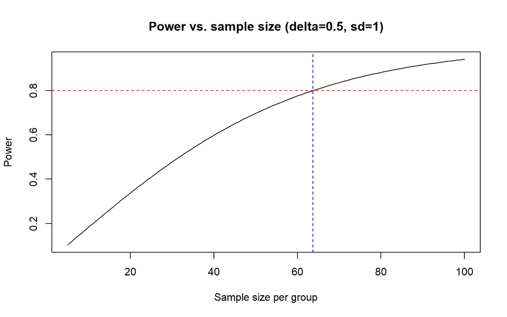

```r
n.seq <- seq(5, 100, by=1)
power.seq <- sapply(n.seq, function(n) power.t.test(n=n, delta=0.5, sd=1, sig.level=0.05)$power)
plot(n.seq, power.seq, type="l", xlab="Sample size per group", ylab="Power",
     main="Power vs. sample size (delta=0.5, sd=1)")
abline(h=0.80, lty=2, col="red")
abline(v=power.t.test(delta=0.5, sd=1, sig.level=0.05, power=0.80)$n, lty=2, col="blue")
```

The curve rises steeply at first and then flattens: early additions to sample size buy substantial increases in power, but beyond a certain point, additional samples yield diminishing returns. The dashed lines mark the conventional 80% power threshold and the corresponding sample size from our earlier calculation.

# 11 Power for Other Designs

The logic above extends to other study designs, though the specific R function changes. For one-way ANOVA, `power.anova.test()` calculates power or sample size for comparing means across more than two groups, given the number of groups, the variance of the group means (between-group variability), and the within-group variance. For proportions, such as comparing event rates between two groups, `power.prop.test()` is the analog of `power.t.test()` for binary outcomes, such as comparing the proportion of patients responding to treatment vs. placebo. For correlation, the `pwr` package (not part of base R; install with `install.packages("pwr")`) provides `pwr.r.test()` for determining the sample size needed to detect a correlation of a given magnitude, and includes power calculations for chi-square tests, general linear models, and more.

```r
power.prop.test(p1=0.3, p2=0.5, sig.level=0.05, power=0.80)
```

```
##
##      Two-sample comparison of proportions power calculation
##
##               n = 92.99884
##              p1 = 0.3
##              p2 = 0.5
##       sig.level = 0.05
##           power = 0.8
##     alternative = two.sided
##
## NOTE: n is number in *each* group
```

The example above calculates the sample size needed per group to detect a difference between a 30% response rate and a 50% response rate, at conventional significance and power. Notice that detecting a smaller absolute difference, or a difference in proportions closer to 0.5 (where variability is highest), requires a substantially larger sample size, a pattern worth building intuition for, since it directly affects the feasibility of a proposed study design.

# 12 A Practical Note

Power analysis is most useful, and most honestly used, when it is performed *before* data collection, using an effect size that reflects what would be practically or clinically meaningful, not an effect size estimated after looking at the data already collected (“post hoc power,” computed using the observed effect size from a completed, non-significant study, is a common but statistically circular practice that should be avoided; see the homework for further discussion). The choice of effect size is itself often the hardest and most consequential part of a power analysis, typically informed by pilot studies, prior literature, or a minimum clinically important difference established by domain experts.